# L1

# Design Types

## Plan-and-Document

- Very detailed plan
- Update documentation before changing code

### Waterfall approach

- Steps:
  1. Requirements analysis and specification
  2. Architectural design
  3. Implementation and integration
  4. Verification
  5. Operations and maintenance
- Month long phases
- **Brook’s Law**: adding manpower to a late project can make it later
  - $O(N^{2})$ vs $O(N)$ b/c coordination

## Agile

- **Peres’ Law**: Software change is a fact of life, so don’t try to solve it, but work with it
- Individuals and interactions over processes and tools
- Working software over comprehensive documentation
- Customer collaboration over contract negotiation
- Responding to change over following a plan
- **Continuous improvement**
  - Iterative design (~1-2 weeks)
- Use **user stories** over detailed requirements elicitation
- Not always the best

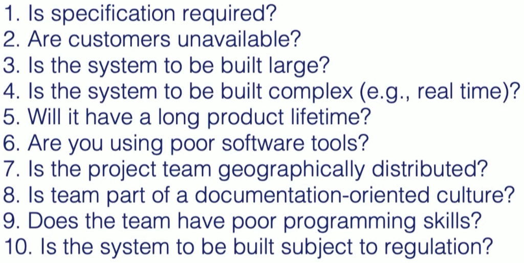

  - Screenshot_2023-08-24_at_8.49.25_PM.png

### Extreme Programming

- Take agile to the extreme
- Make iterations as short as possible
- Make things as simple as possible
- Test all of the time (**test driven development**: write tests before code)
- Review code continuously
  - GitHub PR

# Testing and Quality

- **Product quality** / fitness for use: business value for customer and manufacturer
- **Software quality**: Satisfies customer needs and is easy for developer to debug and enhance
- **Software QA**: ensure quality and improve processes in SW organization

## Verification and Validation

- **Verification**: Did you build the thing right?
  - Did you meet the spec?
- **Validation**: Did you build the right thing?
  - Is it what the customer wants?
  - Was the spec correct
  - More important for SW

## Testing

- Test in levels
- **Coverage**: % of system exercises by test suite
- **Unit test**: Single method does what was expected
- **Module / functional test**: Test across individual units
- **Integration test**: Interfaces between units have consistent assumptions, communicate correctly
- **System / acceptance test**: Integrated program meets its specifications

# Productivity

- Moore’s law applied to SW complexity
1. Clarity via conciseness
2. Synthesis: have code that writes code
3. Reuse: reuse stuff when possible
4. Automation and Tools

## Clarity via Conciseness

- Raise the level of abstraction
  - More functionality, fewer words
- Exploit high level languages for conciseness

## Synthesis

- Common uses are templating and code generators

## Reuse (DRY it out)

- Identify commonalities and abstract it
1. Procedures and functions
2. Standardized libraries
3. Object oriented programming: reuse and manage *collections* of tasks
4. **Design patterns**: reuse a general strategy even if implementation varies
5. LLMs and prompt reuse

## Automation vs Manual Task

- Saves time and improves accuracy
  - eg: make
- **New tool desiderata**: learning curve justifies productivity gained
- **Learn new tools**!

# Deploying SaaS SOA and Utility Computing

## SaaS > SWS (shrink-wrapped software)

- No install / upgrade / compatibility issues
- Data stored safely, persistently on servers
- Easy group access to data for collaboration
- Simpler to keep 1 copy rather than multiple
- Upgrades for all users immediately
- Can beta test on subset of users

## Service Oriented Architecture

- Subsystems independent as if in separate datacenters
- Can recombine to make new services
- Must be interacted with through individual API

### 3 Demands

- Communication
- Scalability
- Dependability
- Done with warehouse-scale computers
  - Plugability and dependency

## Deploying SaaS: Browser and Mobile

- ~50% smartphone penetration
  - Apps should be either mobile-friendly or mobile-first
- Should have responsible deign
- Think about interactions (how someone uses it physically)

## Web Techs

- HTML: Markup only
- CSS: Styling only
  - Bootstrap: mobile-first framework (integrated into rails)
- Progressive web app (PWA): packages app to be downloaded or function offline
  - Can do progressive updates which Wrapped, and Native cant
- Wrapped apps: apps in containers, no progressive updates
- Native apps: built for a specific platform (better access to HW)